# R course - Do PSA values differ by tumor stage?

Author

Leonie Schreck

Published

June 16, 2023

## Introduction

Prostate-specific antigen (PSA) is a protein made by the prostate gland. The amount of PSA may be higher in men who have prostate cancer. We wanted to study if PSA values differ by prostate cancer tumor stage.

#### **Aim**

In a first step, we aimed to describe age, preoperative PSA values and tumor stage and in a second step, we assessed if preoperative PSA values differ by tumor stage.

## Data

We used the following R libraries.

```r
library(lubridate)
library(ggplot2)
library(here)
library(gtsummary)
library(tidyverse)
library(readr)
library(medicaldata)
```

We loaded the “blood_storage” data set from the package “medicaldata”. This data set contains data on 316 men who had undergone radical prostatectomy and received transfusion during or within 30 days of the surgical procedure and had available prostate serum antigen (PSA) data.

```r
blood <- medicaldata::blood_storage
```

#### **Data cleaning**

We changed the variable class of tumor stage to a factor and excluded missing values for tumor stage and PSA.

```r
blood <- blood |> mutate(T.Stage = factor(T.Stage, levels=c(1,2), labels=c("low","high")))
blood <- blood |> filter(!is.na(T.Stage)) |> filter(!is.na(PreopPSA))
```

#### Descriptive table

A descriptive table of our three variables of interest can be found below:

```r
tabl_summary<-
  blood |>
    select(Age, PreopPSA, T.Stage) |>
  tbl_summary(
    type = all_continuous() ~ "continuous2",
    statistic = all_continuous() ~ c("{mean} ({sd})",
                                     "{median} ({p25}, {p75})",
                                     "{min}, {max}"))
tabl_summary
```

| **Characteristic** | **N = 301**<sup>1</sup> |
| --- | --- |
| Age |  |
| Mean (SD) | 61 (7) |
| Median (IQR) | 62 (56, 66) |
| Range | 38, 79 |
| PreopPSA |  |
| Mean (SD) | 8.3 (6.1) |
| Median (IQR) | 6.2 (5.0, 9.0) |
| Range | 1.3, 40.1 |
| T.Stage |  |
| low | 267 (89%) |
| high | 34 (11%) |

<sup>1</sup> n (%)

#### Visualization

We visualized the continuous variables age and PSA with box plots.

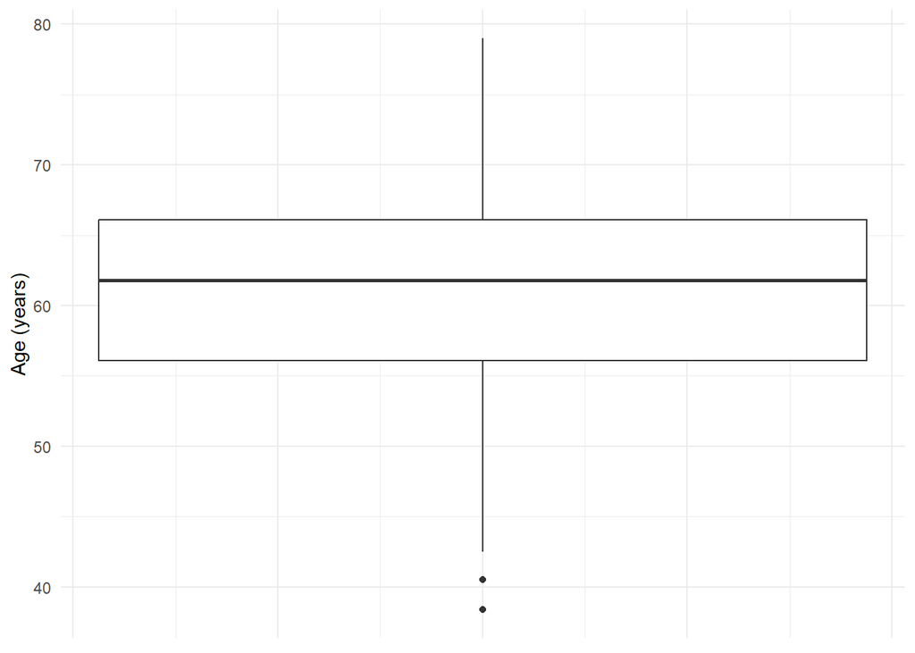

```r
plot0 <- ggplot(blood, aes(y=Age)) +
    geom_boxplot() +
    ylab("Age (years)") +
        theme_minimal()+
    theme(axis.text.x = element_blank())
plot0
```

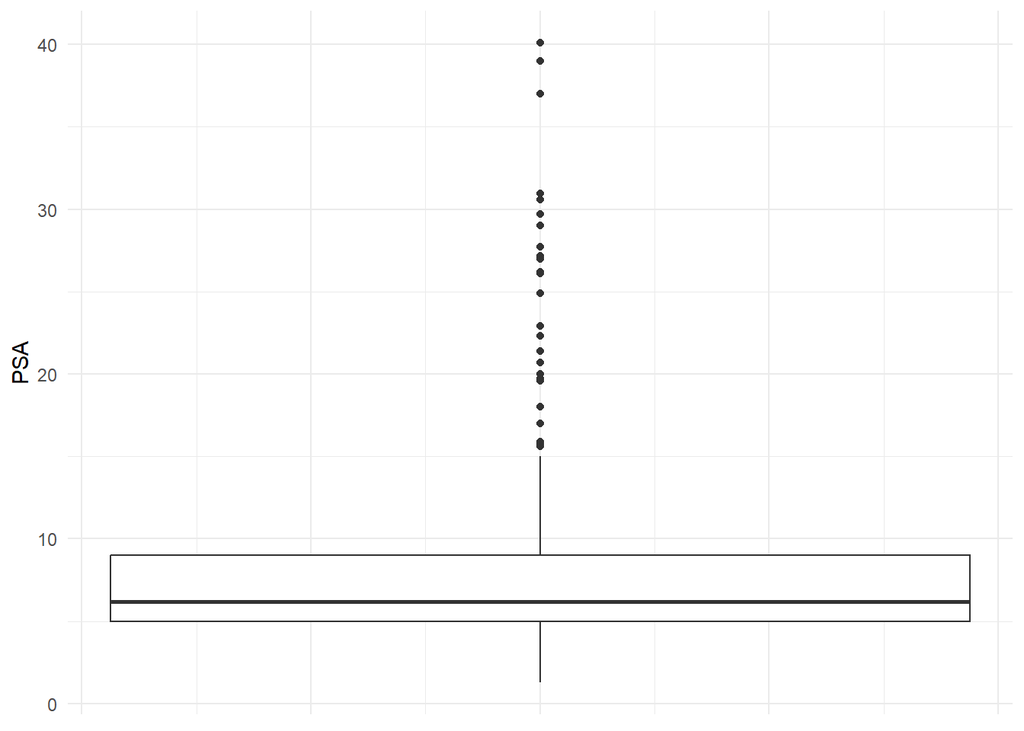

```r
plota <- ggplot(blood, aes(y=PreopPSA)) +
    geom_boxplot() +
    ylab("PSA") +
        theme_minimal()+
    theme(axis.text.x = element_blank())
plota
```

#### Normality

We check for normality. PSA does not seem to be normally distributed.

```r
shapiro.test(blood$PreopPSA)
```

```
    Shapiro-Wilk normality test

data:  blood$PreopPSA
W = 0.7056, p-value < 2.2e-16
```

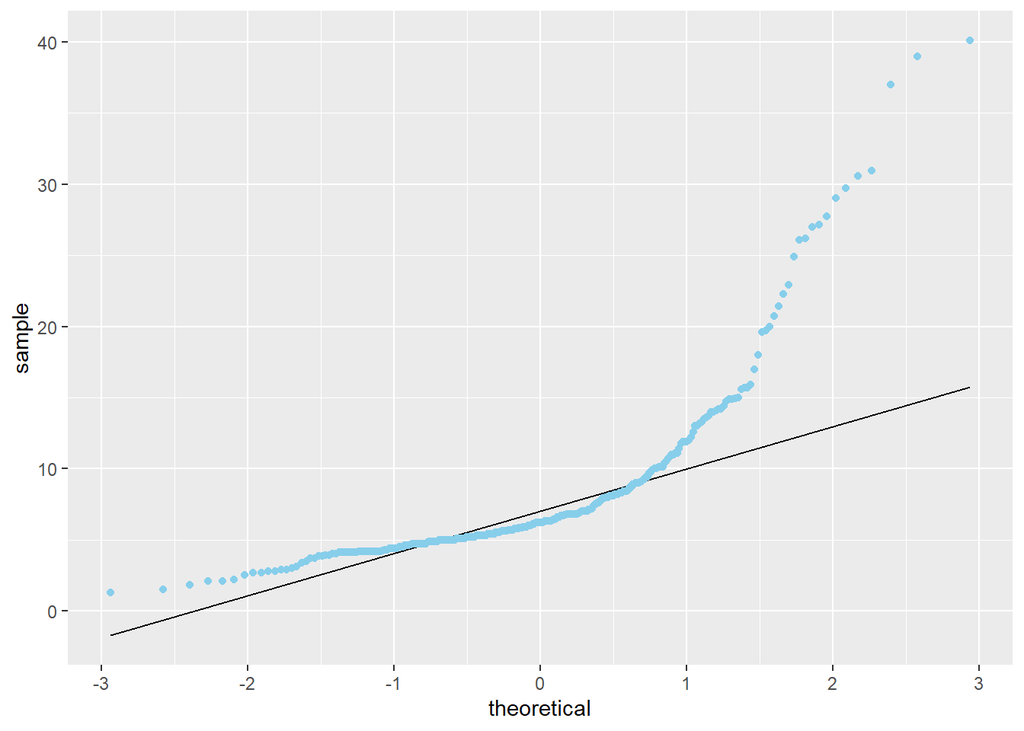

```r
blood %>%
  ggplot(aes(sample = PreopPSA)) +
  geom_qq_line(distribution = stats::qnorm) +
  geom_qq(color = "skyblue", distribution = stats::qnorm)
```

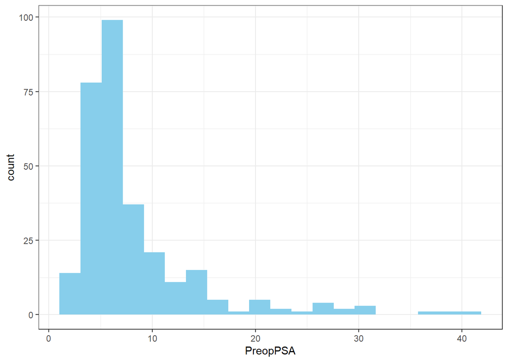

```r
plot2 <- blood %>%
  ggplot(aes(PreopPSA)) +
  geom_histogram(fill = "skyblue",
                 bins = 20) +
  theme_bw()
plot2
```

#### Analysis

We checked the difference between PSA levels in high and low stage prostate cancer.

```r
tabl_summary2<-
  blood |>
    select(Age, PreopPSA, T.Stage) |>
  tbl_summary(
    by = T.Stage,
    type = all_continuous() ~ "continuous2",
    statistic = all_continuous() ~ c("{mean} ({sd})",
                                     "{median} ({p25}, {p75})",
                                     "{min}, {max}"))
tabl_summary2
```

| **Characteristic** | **low**, N = 267 | **high**, N = 34 |
| --- | --- | --- |
| Age |  |  |
| Mean (SD) | 61 (7) | 61 (8) |
| Median (IQR) | 62 (56, 66) | 61 (54, 68) |
| Range | 38, 79 | 43, 77 |
| PreopPSA |  |  |
| Mean (SD) | 7.7 (4.9) | 12.8 (10.9) |
| Median (IQR) | 6.2 (5.0, 8.7) | 7.4 (4.7, 21.6) |
| Range | 1.3, 39.0 | 3.4, 40.1 |

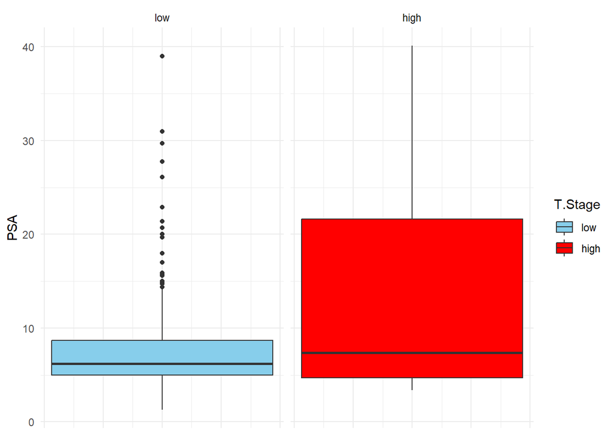

```r
 plot1 <- ggplot(blood, aes(y=PreopPSA, fill=T.Stage)) +
    geom_boxplot() +
    ylab("PSA") +
    facet_wrap(~T.Stage) +
    theme_minimal()+
    theme(axis.text.x = element_blank())+
    scale_fill_manual(
    values = c("skyblue", "red"))
 plot1
```

We performed a Wilcoxon rank sum test to compare the PSA levels in both tumor stage groups.

```r
wilcox.test(blood$PreopPSA[blood$T.Stage=="low"], blood$PreopPSA[blood$T.Stage=="high"])
```

```
    Wilcoxon rank sum test with continuity correction

data:  blood$PreopPSA[blood$T.Stage == "low"] and blood$PreopPSA[blood$T.Stage == "high"]
W = 3809, p-value = 0.1269
alternative hypothesis: true location shift is not equal to 0
```

## Conclusion

There is little evidence that the preoperative PSA levels differ by tumor stage.